# Adversarial Search: Playing Connect 4

### Playtime [5 points]

Let the Minimax Search agent play a random agent on a $4 \times 4$ board. Analyze wins, losses and draws.

```
Number of nodes searched: 62889
Agent (1) chose column: 0, with value: 0
Updated board:
```

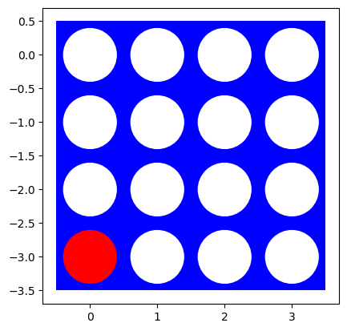

```
Random agent (-1) chose column: 0
Updated board:
```

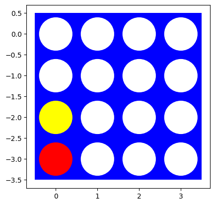

```
Number of nodes searched: 27522
Agent (1) chose column: 0, with value: 0
Updated board:
```

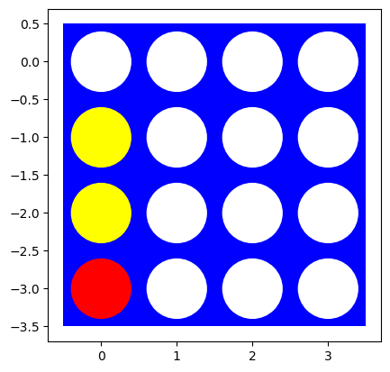

```
Random agent (-1) chose column: 2
Updated board:
```

[figure not shown]

```
Number of nodes searched: 6371
Agent (1) chose column: 0, with value: 0
Updated board:
```

[figure not shown]

```
Random agent (-1) chose column: 3
Updated board:
```

[figure not shown]

```
Number of nodes searched: 632
Agent (1) chose column: 1, with value: 0
Updated board:
```

[figure not shown]

```
Random agent (-1) chose column: 1
Updated board:
```

[figure not shown]

```
Number of nodes searched: 176
Agent (1) chose column: 1, with value: 0
Updated board:
```

[figure not shown]

```
Random agent (-1) chose column: 1
Updated board:
```

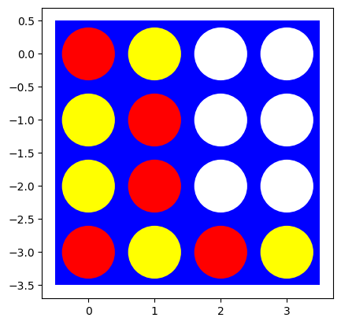

```
Number of nodes searched: 30
Agent (1) chose column: 2, with value: 0
Updated board:
```

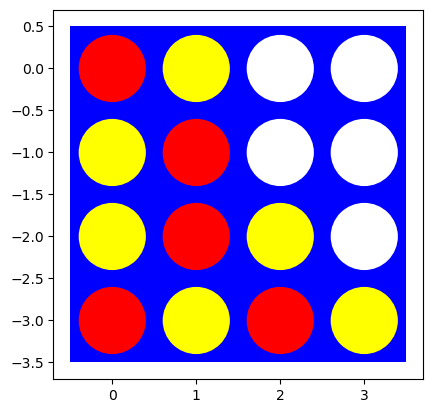

```
Random agent (-1) chose column: 3
Updated board:
```

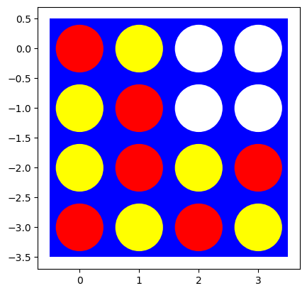

```
Number of nodes searched: 14
Agent (1) chose column: 2, with value: 0
Updated board:
```

[4 more figures not shown]

```
The game is a draw!
```

```python
import math
import numpy as np
import random

class Connect4Agent:
    def __init__(self):
        self.DEBUG = 1 # For debugging purposes
        self.COUNT = 0

    def alpha_beta_search(self, board, player=1):
        """Start the search."""
        self.COUNT = 0
        value, move = self.max_value_ab(board, player, -math.inf, +math.inf)

        if self.DEBUG >= 1:
            print(f"Number of nodes searched: {self.COUNT}")

        return {"move": move, "value": value}

    def max_value_ab(self, state, player, alpha, beta):
        """Player's best move."""
        self.COUNT += 1
        v = self.utility(state, player)
        if self.DEBUG >= 2:
            print(f"max: {state} [alpha,beta]=[{alpha},{beta}] v={v}")
        if v is not None:
            if self.DEBUG >= 2:
                print(f" found terminal state. backtracking.")
            return v, None

        v, move = -math.inf, None

        for a in self.actions(state):
            v2, _ = self.min_value_ab(self.result(state, player, a), player, alpha, beta)
            if self.DEBUG >= 2:
                print(f"max: {state} (backtracked) [alpha,beta]=[{alpha},{beta}] v={v2}")

            if v2 > v:
                v, move = v2, a
                alpha = max(alpha, v)
                if v >= beta:
                    if self.DEBUG >= 2:
                        print(f" v >= beta ({v} >= {beta}): pruning remaining subtree.")
                    return v, move

        return v, move

    def min_value_ab(self, state, player, alpha, beta):
        """Opponent's best response."""
        self.COUNT += 1
        v = self.utility(state, player)
        if self.DEBUG >= 2:
            print(f"min: {state} [alpha,beta]=[{alpha},{beta}] v={v}")
        if v is not None:
            if self.DEBUG >= 2:
                print(f" found terminal state. backtracking.")
            return v, None

        v, move = +math.inf, None

        for a in self.actions(state):
            v2, _ = self.max_value_ab(self.result(state, self.other(player), a), player, alpha, beta)
            if self.DEBUG >= 2:
                print(f"min: {state} (backtracked) [alpha,beta]=[{alpha},{beta}] v={v2}")

            if v2 < v:
                v, move = v2, a
                beta = min(beta, v)
                if v <= alpha:
                    if self.DEBUG >= 2:
                        print(f" v <= alpha ({v} <= {alpha}): pruning remaining subtree.")
                    return v, move

        return v, move

    def utility(self, state, player):
        """Evaluate the board state."""
        if self.is_winner(state, player):
            return 4 # Player wins
        elif self.is_winner(state, self.other(player)):
            return -4 # Opponent wins
        elif self.is_full(state):
            return 0 # Draw
        return None # Game continues

    def actions(self, state):
        """Return a list of valid actions (columns to drop a piece)."""
        valid_moves = []

        for col in range(4): # Assuming a 4-column grid
            if state[0][col] == 0: # Check if the column is not full
                valid_moves.append(col)

        return valid_moves

    def result(self, state, player, action):
        """Return the resulting state after applying the action."""
        new_state = state.copy()
        for row in range(3, -1, -1): # Find the first available row in the column
            if new_state[row][action] == 0:
                new_state[row][action] = 1 if player == 1 else -1
                break
        return new_state

    def is_winner(self, state, player):
        """Check if the player has won the game."""
        for row in range(4):
            for col in range(4):
                if state[row][col] == (1 if player == 1 else -1):
                    # Check horizontal
                    if col + 3 < 4 and all(state[row][col + i] == state[row][col] for i in range(4)):
                        return True
                    # Check vertical
                    if row + 3 < 4 and all(state[row + i][col] == state[row][col] for i in range(4)):
                        return True
                    # Check diagonal /
                    if row + 3 < 4 and col + 3 < 4 and all(state[row + i][col + i] == state[row][col] for i in range(4)):
                        return True
                    # Check diagonal \
                    if row - 3 >= 0 and col + 3 < 4 and all(state[row - i][col + i] == state[row][col] for i in range(4)):
                        return True
        return False

    def is_full(self, state):
        """Check if the board is full (draw condition)."""
        return all(state[0][col] != 0 for col in range(4))

    def other(self, player):
        """Return the opponent's player."""
        return -1 if player == 1 else 1

def random_agent(board):
    """Choose a random valid column."""
    valid_moves = [col for col in range(4) if board[0][col] == 0]
    return random.choice(valid_moves) if valid_moves else None



# Example of using the agent with a predefined board
board = np.array([
    [0, 0, 0, 0],
    [0, 0, 0, 0],
    [0, 0, 0, 0],
    [0, 0, 0, 0]
])

# Initialize the agent (for player 1)
agent = Connect4Agent()
player = 1

while True:
    # Run the agent's alpha-beta search to get the next move for player 1
    move_info = agent.alpha_beta_search(board, player=1)

    # Print the chosen move and board value
    print(f"Agent (1) chose column: {move_info['move']}, with value: {move_info['value']}")

    # Update the board with the chosen move
    if move_info['move'] is not None:
        board = agent.result(board, player, move_info['move'])

    # Print the updated board
    print("Updated board:")
    visualize(board)

    # Check for win condition for player 1
    if agent.utility(board, player) == 4:
        print("Player 1 wins!")
        break

    # Random agent's turn
    player = agent.other(player)
    move = random_agent(board)

    if move is not None:
        board = agent.result(board, player, move)
        print(f"Random agent (-1) chose column: {move}")

    # Print the updated board
    print("Updated board:")
    visualize(board)

    # Check for win condition for player '-1'
    if agent.utility(board, player) == -4:
        print("Player -1 wins!")
        break

    # Check for draw
    if agent.is_full(board):
        print("The game is a draw!")
        break
```

```python
def game_random_minmax():
    # Example of using the agent with a predefined board
    board = np.array([[0, 0, 0, 0, 0 ,0, 0],
                     [0, 0, 0 ,0 ,0 ,0 ,0],
                     [0, 0, 0, 0, 0 ,0 ,0],
                     [0, 0, 0, 0 ,0 ,0 ,0],
                     [0, 0, 0, 0, 0 ,0 ,0],
                     [0, 0, 0 ,0 ,0 ,0 ,0]])

    # Initialize the agent (for player 1)
    agent = Connect4Agent()
    player = 1

    while True:
        # Run the agent's alpha-beta search to get the next move for player 1
        move_info = agent.alpha_beta_search(board, player=1)

        # Print the chosen move and board value
        print(f"Agent (1) chose column: {move_info['move']}, with value: {move_info['value']}")

        # Update the board with the chosen move
        if move_info['move'] is not None:
            board = agent.result(board, player, move_info['move'])

        # Print the updated board
        print("Updated board:")
        visualize(board)

        # Check for win condition for player 1
        if agent.utility(board, player) == 4:
            print("Player 1 wins!")
            break

        # Random agent's turn
        player = agent.other(player)
        move = random_agent(board)

        if move is not None:
            board = agent.result(board, player, move)
            print(f"Random agent (-1) chose column: {move}")

        # Print the updated board
        print("Updated board:")
        visualize(board)

        # Check for win condition for player '-1'
        if agent.utility(board, player) == -4:
            print("Player -1 wins!")
            break

        # Check for draw
        if agent.is_full(board):
            print("The game is a draw!")
            break
    return agent.utility(board, player)
```

```python
from IPython.display import clear_output
util=[]
for i in range(100):
    print(i)
    util.append(game_random_minmax())
    clear_output()
```

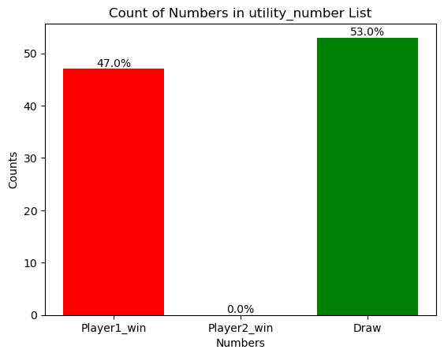

```python
labels = ['Player1_win', 'Player2_win', 'Draw']
counts = [util.count(4), util.count(-4), util.count(0)]
import matplotlib.pyplot as plt

plt.bar(labels, counts, color=[ 'red','yellow', 'green'])
plt.xlabel('Numbers')
plt.ylabel('Counts')
plt.title('Count of Numbers in utility_number List')
total_count = util.count(4)+ util.count(-4)+ util.count(0)
percentage_4 = (util.count(4)/ total_count) * 100
percentage_minus_4 = (util.count(-4) / total_count) * 100
percentage_0 = (util.count(0) / total_count) * 100
percentages = [percentage_4, percentage_minus_4, percentage_0]
for i, count in enumerate(counts):
    plt.text(i, count, f'{percentages[i]:.1f}%', ha='center', va='bottom')
plt.show()
```

## Task 4: Heuristic Alpha-Beta Tree Search

### Heuristic evaluation function [15 points]

Define and implement a heuristic evaluation function. Make sure that the heuristic value stays in the correct range.

my heuristic evaluation function helps the AI assess the Connect Four board by scoring sequences of four consecutive cells based on favorable or unfavorable configurations. It rewards the player's own pieces and penalizes the opponent's. The overall board score, considering horizontal, vertical, and diagonal windows, is then normalized to a range between -1 and 1. This score guides the AI's Alpha-Beta decision-making to choose moves that maximize its chances of winning or block the opponent's moves.

[figure not shown]

[figure not shown]

[figure not shown]

[figure not shown]

[figure not shown]

[figure not shown]

[figure not shown]

[figure not shown]

[figure not shown]

[figure not shown]

[figure not shown]

[figure not shown]

[5 more figures not shown]

```
Player -1 wins!
```

```python
ROWS = 6
COLS = 7
PLAYER1 = 1
PLAYER2 = -1

# Function to create an empty board
def create_board():
    return np.zeros((ROWS, COLS))

# Function to check if the column is valid
def is_valid_location(board, col):
    return board[ROWS-1][col] == 0

# Function to get the next open row in a column
def get_next_open_row(board, col):
    for r in range(ROWS):
        if board[r][col] == 0:
            return r

# Function to place a disc on the board
def drop_piece(board, row, col, piece):
    board[row][col] = piece

# Heuristic evaluation function
def evaluate_window(window, piece):
    score = 0
    opp_piece = PLAYER2 if piece == PLAYER1 else PLAYER1
    if window.count(piece) == 4:
        score += 100
    elif window.count(piece) == 3 and window.count(0) == 1:
        score += 5
    elif window.count(opp_piece) == 3 and window.count(0) == 1:
        score -= 4
    return score

# Score the board based on various factors
def score_position(board, piece):
    score = 0

    # Score center column
    center_array = list(board[:, COLS//2])
    score += center_array.count(piece) * 3

    # Score horizontal lines
    for r in range(ROWS):
        row_array = list(board[r])
        for c in range(COLS-3):
            window = row_array[c:c+4]
            score += evaluate_window(window, piece)

    # Score vertical lines
    for c in range(COLS):
        col_array = list(board[:, c])
        for r in range(ROWS-3):
            window = col_array[r:r+4]
            score += evaluate_window(window, piece)

    # Score positive diagonals
    for r in range(ROWS-3):
        for c in range(COLS-3):
            window = [board[r+i][c+i] for i in range(4)]
            score += evaluate_window(window, piece)

    # Score negative diagonals
    for r in range(3, ROWS):
        for c in range(COLS-3):
            window = [board[r-i][c+i] for i in range(4)]
            score += evaluate_window(window, piece)

    # Normalize score to be between -1 and 1 (example)
    max_score = 100 * (ROWS * COLS // 4)  # Max possible score (conservative estimate)
    min_score = -100 * (ROWS * COLS // 4)  # Min possible score (conservative estimate)
    score = (score - min_score) / (max_score - min_score) * 2 - 1  # Normalize to range [-1, 1]

    return score

# Alpha-Beta algorithm for decision-making
def alpha_beta(board, depth, alpha, beta, maximizing_player):
    valid_locations = [c for c in range(COLS) if is_valid_location(board, c)]
    is_terminal = len(valid_locations) == 0

    if depth == 0 or is_terminal:
        return score_position(board, PLAYER1), None

    if maximizing_player:
        value = -np.inf
        column = np.random.choice(valid_locations)
        for col in valid_locations:
            row = get_next_open_row(board, col)
            temp_board = board.copy()
            drop_piece(temp_board, row, col, PLAYER1)
            new_score, _ = alpha_beta(temp_board, depth-1, alpha, beta, False)
            if new_score > value:
                value = new_score
                column = col
            alpha = max(alpha, value)
            if alpha >= beta:
                break
        return value, column
    else:
        value = np.inf
        column = np.random.choice(valid_locations)
        for col in valid_locations:
            row = get_next_open_row(board, col)
            temp_board = board.copy()
            drop_piece(temp_board, row, col, PLAYER2)
            new_score, _ = alpha_beta(temp_board, depth-1, alpha, beta, True)
            if new_score < value:
                value = new_score
                column = col
            beta = min(beta, value)
            if beta <= alpha:
                break
        return value, column

# Function to check for a win
def is_winning_move(board, piece):
    # Check horizontal, vertical, and both diagonals
    for r in reversed(range(ROWS)):
        for c in range(COLS-3):
            if board[r][c] == piece and board[r][c+1] == piece and board[r][c+2] == piece and board[r][c+3] == piece:
                return True
    for r in reversed(range(ROWS-3)):
        for c in range(COLS):
            if board[r][c] == piece and board[r+1][c] == piece and board[r+2][c] == piece and board[r+3][c] == piece:
                return True
    for r in reversed(range(ROWS-3)):
        for c in range(COLS-3):
            if board[r][c] == piece and board[r+1][c+1] == piece and board[r+2][c+2] == piece and board[r+3][c+3] == piece:
                return True
    for r in reversed(range(3, ROWS)):
        for c in range(COLS-3):
            if board[r][c] == piece and board[r-1][c+1] == piece and board[r-2][c+2] == piece and board[r-3][c+3] == piece:
                return True
    return False



def play_game():
    board = create_board()
    game_over = False
    turn = 0  # 0 for Player 1, 1 for Player 2
    depth = 4  # Search depth for the AI

    while not game_over:
        # Alternate between Player 1 and Player 2
        current_player = PLAYER1 if turn % 2 == 0 else PLAYER2

        # Get the best move using Alpha-Beta (from last column to first)
        valid_locations = [c for c in range(COLS) if is_valid_location(board, c)]
        valid_locations.reverse()  # Reverse the order to start from the last column
        score, col = alpha_beta(board, depth, -np.inf, np.inf, current_player == PLAYER1)

        # Drop the piece on the board
        row = get_next_open_row(board, col)
        drop_piece(board, row, col, current_player)

        # Print the current board
        visualize(np.flip(board))

        # Check if the current player has won
        if is_winning_move(board, current_player):
            print(f"Player {current_player} wins!")
            game_over = True
        elif np.all(board != 0):  # Check if the board is full (draw)
            print("It's a draw!")
            game_over = True

        # Switch turn
        turn += 1

# Start the game
play_game()
```

### Cutting Off Search [10 points]

Modify your minimax search with alpha-beta pruning to cut off search at a specified depth and use the heuristic evaluation function. Experiment with different cutoff values.

```python
import numpy as np

ROWS = 6
COLS = 7
PLAYER1 = 1
PLAYER2 = -1

# Function to create an empty board
def create_board():
    return np.zeros((ROWS, COLS))

# Function to check if the column is valid
def is_valid_location(board, col):
    return board[ROWS-1][col] == 0

# Function to get the next open row in a column
def get_next_open_row(board, col):
    for r in range(ROWS):
        if board[r][col] == 0:
            return r

# Function to place a disc on the board
def drop_piece(board, row, col, piece):
    board[row][col] = piece

# Heuristic evaluation function
def evaluate_window(window, piece):
    score = 0
    opp_piece = PLAYER2 if piece == PLAYER1 else PLAYER1
    if window.count(piece) == 4:
        score += 100
    elif window.count(piece) == 3 and window.count(0) == 1:
        score += 5
    elif window.count(opp_piece) == 3 and window.count(0) == 1:
        score -= 4
    return score

# Score the board based on various factors
def score_position(board, piece):
    score = 0
    center_array = list(board[:, COLS//2])
    score += center_array.count(piece) * 3

    # Score horizontal lines
    for r in range(ROWS):
        row_array = list(board[r])
        for c in range(COLS-3):
            window = row_array[c:c+4]
            score += evaluate_window(window, piece)

    # Score vertical lines
    for c in range(COLS):
        col_array = list(board[:, c])
        for r in range(ROWS-3):
            window = col_array[r:r+4]
            score += evaluate_window(window, piece)

    # Score positive diagonals
    for r in range(ROWS-3):
        for c in range(COLS-3):
            window = [board[r+i][c+i] for i in range(4)]
            score += evaluate_window(window, piece)

    # Score negative diagonals
    for r in range(3, ROWS):
        for c in range(COLS-3):
            window = [board[r-i][c+i] for i in range(4)]
            score += evaluate_window(window, piece)

    return score

# Alpha-Beta algorithm for decision-making with depth cutoff
def alpha_beta(board, depth, alpha, beta, maximizing_player):
    valid_locations = [c for c in range(COLS) if is_valid_location(board, c)]
    is_terminal = len(valid_locations) == 0

    if depth == 0 or is_terminal: # Cutoff condition
        return score_position(board, PLAYER1), None

    if maximizing_player:
        value = -np.inf
        column = np.random.choice(valid_locations)
        for col in valid_locations:
            row = get_next_open_row(board, col)
            temp_board = board.copy()
            drop_piece(temp_board, row, col, PLAYER1)
            new_score, _ = alpha_beta(temp_board, depth-1, alpha, beta, False)
            if new_score > value:
                value = new_score
                column = col
            alpha = max(alpha, value)
            if alpha >= beta:
                break
        return value, column
    else:
        value = np.inf
        column = np.random.choice(valid_locations)
        for col in valid_locations:
            row = get_next_open_row(board, col)
            temp_board = board.copy()
            drop_piece(temp_board, row, col, PLAYER2)
            new_score, _ = alpha_beta(temp_board, depth-1, alpha, beta, True)
            if new_score < value:
                value = new_score
                column = col
            beta = min(beta, value)
            if beta <= alpha:
                break
        return value, column

# Function to check for a win (already implemented in your original code)

def play_game():
    board = create_board()
    game_over = False
    turn = 0 # 0 for Player 1, 1 for Player 2
    depth = 4 # Search depth for the Agent

    while not game_over:
        current_player = PLAYER1 if turn % 2 == 0 else PLAYER2

        # Get the best move using Alpha-Beta
        score, col = alpha_beta(board, depth, -np.inf, np.inf, current_player == PLAYER1)

        # Drop the piece on the board
        row = get_next_open_row(board, col)
        drop_piece(board, row, col, current_player)

        # Print the current board
        visualize(np.flip(board, 0)) # Visualize
        # Print the current board


        # Check for win or draw
        if is_winning_move(board, current_player):
            print(f"Player {current_player} wins!")
            game_over = True
        elif np.all(board != 0): # Check for draw
            print("It's a draw!")
            game_over = True

        # Switch turns
        turn += 1

        # Start the game
play_game()
```

```
Player -1 wins!
```

Experiment with the same manually created boards as above to check if the agent spots wining opportunities.

```python
import numpy as np

ROWS = 6
COLS = 7
PLAYER1 = 1
PLAYER2 = -1

# Function to create an empty board
def create_board():
    return np.zeros((ROWS, COLS))

# Function to check if the column is valid
def is_valid_location(board, col):
    return board[ROWS-1][col] == 0

# Function to get the next open row in a column
def get_next_open_row(board, col):
    for r in range(ROWS):
        if board[r][col] == 0:
            return r

# Function to place a disc on the board
def drop_piece(board, row, col, piece):
    board[row][col] = piece

# Heuristic evaluation function
def evaluate_window(window, piece):
    score = 0
    opp_piece = PLAYER2 if piece == PLAYER1 else PLAYER1
    if window.count(piece) == 4:
        score += 100
    elif window.count(piece) == 3 and window.count(0) == 1:
        score += 5
    elif window.count(opp_piece) == 3 and window.count(0) == 1:
        score -= 4
    return score

# Score the board based on various factors
def score_position(board, piece):
    score = 0
    center_array = list(board[:, COLS//2])
    score += center_array.count(piece) * 3

    # Score horizontal lines
    for r in range(ROWS):
        row_array = list(board[r])
        for c in range(COLS-3):
            window = row_array[c:c+4]
            score += evaluate_window(window, piece)

    # Score vertical lines
    for c in range(COLS):
        col_array = list(board[:, c])
        for r in range(ROWS-3):
            window = col_array[r:r+4]
            score += evaluate_window(window, piece)

    # Score positive diagonals
    for r in range(ROWS-3):
        for c in range(COLS-3):
            window = [board[r+i][c+i] for i in range(4)]
            score += evaluate_window(window, piece)

    # Score negative diagonals
    for r in range(3, ROWS):
        for c in range(COLS-3):
            window = [board[r-i][c+i] for i in range(4)]
            score += evaluate_window(window, piece)

    return score

# Alpha-Beta algorithm for decision-making with depth cutoff
def alpha_beta(board, depth, alpha, beta, maximizing_player):
    valid_locations = [c for c in range(COLS) if is_valid_location(board, c)]
    is_terminal = len(valid_locations) == 0

    if depth == 0 or is_terminal: # Cutoff condition
        return score_position(board, PLAYER1), None

    if maximizing_player:
        value = -np.inf
        column = np.random.choice(valid_locations)
        for col in valid_locations:
            row = get_next_open_row(board, col)
            temp_board = board.copy()
            drop_piece(temp_board, row, col, PLAYER1)
            new_score, _ = alpha_beta(temp_board, depth-1, alpha, beta, False)
            if new_score > value:
                value = new_score
                column = col
            alpha = max(alpha, value)
            if alpha >= beta:
                break
        return value, column
    else:
        value = np.inf
        column = np.random.choice(valid_locations)
        for col in valid_locations:
            row = get_next_open_row(board, col)
            temp_board = board.copy()
            drop_piece(temp_board, row, col, PLAYER2)
            new_score, _ = alpha_beta(temp_board, depth-1, alpha, beta, True)
            if new_score < value:
                value = new_score
                column = col
            beta = min(beta, value)
            if beta <= alpha:
                break
        return value, column

# Function to check for a win (already implemented in your original code)

def play_game1():
    board = create_board()
    game_over = False
    turn = 0 # 0 for Player 1, 1 for Player 2
    depth = 4 # Search depth for the Agent

    while not game_over:
        current_player = PLAYER1 if turn % 2 == 0 else PLAYER2

        # Get the best move using Alpha-Beta
        score, col = alpha_beta(board, depth, -np.inf, np.inf, current_player == PLAYER1)

        # Drop the piece on the board
        row = get_next_open_row(board, col)
        drop_piece(board, row, col, current_player)

        # Print the current board
        visualize(np.flip(board, 0)) # Visualize
        # Print the current board


        # Check for win or draw
        if is_winning_move(board, current_player):
            print(f"Player {current_player} wins!")
            game_over = True
        elif np.all(board != 0): # Check for draw
            print("It's a draw!")
            game_over = True

        # Switch turns
        turn += 1

        # Start the game
play_game1()
```

```
Player -1 wins!
```

```python
import numpy as np

ROWS =6
COLS =7
PLAYER1 = 1
PLAYER2 = -1

# Function to create an empty board
def create_board():
    return np.zeros((ROWS, COLS))

# Function to check if the column is valid
def is_valid_location(board, col):
    return board[ROWS-1][col] == 0

# Function to get the next open row in a column
def get_next_open_row(board, col):
    for r in range(ROWS):
        if board[r][col] == 0:
            return r

# Function to place a disc on the board
def drop_piece(board, row, col, piece):
    board[row][col] = piece

# Heuristic evaluation function
def evaluate_window(window, piece):
    score = 0
    opp_piece = PLAYER2 if piece == PLAYER1 else PLAYER1
    if window.count(piece) == 4:
        score += 100
    elif window.count(piece) == 3 and window.count(0) == 1:
        score += 5
    elif window.count(opp_piece) == 3 and window.count(0) == 1:
        score -= 4
    return score

# Score the board based on various factors
def score_position(board, piece):
    score = 0
    center_array = list(board[:, COLS//2])
    score += center_array.count(piece) * 3

    # Score horizontal lines
    for r in range(ROWS):
        row_array = list(board[r])
        for c in range(COLS-3):
            window = row_array[c:c+4]
            score += evaluate_window(window, piece)

    # Score vertical lines
    for c in range(COLS):
        col_array = list(board[:, c])
        for r in range(ROWS-3):
            window = col_array[r:r+4]
            score += evaluate_window(window, piece)

    # Score positive diagonals
    for r in range(ROWS-3):
        for c in range(COLS-3):
            window = [board[r+i][c+i] for i in range(4)]
            score += evaluate_window(window, piece)

    # Score negative diagonals
    for r in range(3, ROWS):
        for c in range(COLS-3):
            window = [board[r-i][c+i] for i in range(4)]
            score += evaluate_window(window, piece)

    return score

# Alpha-Beta algorithm for decision-making with depth cutoff
def alpha_beta(board, depth, alpha, beta, maximizing_player):
    valid_locations = [c for c in range(COLS) if is_valid_location(board, c)]
    is_terminal = len(valid_locations) == 0

    if depth == 0 or is_terminal: # Cutoff condition
        return score_position(board, PLAYER1), None

    if maximizing_player:
        value = -np.inf
        column = np.random.choice(valid_locations)
        for col in valid_locations:
            row = get_next_open_row(board, col)
            temp_board = board.copy()
            drop_piece(temp_board, row, col, PLAYER1)
            new_score, _ = alpha_beta(temp_board, depth-1, alpha, beta, False)
            if new_score > value:
                value = new_score
                column = col
            alpha = max(alpha, value)
            if alpha >= beta:
                break
        return value, column
    else:
        value = np.inf
        column = np.random.choice(valid_locations)
        for col in valid_locations:
            row = get_next_open_row(board, col)
            temp_board = board.copy()
            drop_piece(temp_board, row, col, PLAYER2)
            new_score, _ = alpha_beta(temp_board, depth-1, alpha, beta, True)
            if new_score < value:
                value = new_score
                column = col
            beta = min(beta, value)
            if beta <= alpha:
                break
        return value, column

# Function to check for a win (already implemented in your original code)

def play_game1():
    board = create_board()
    game_over = False
    turn = 0 # 0 for Player 1, 1 for Player 2
    depth = 4 # Search depth for the Agent

    while not game_over:
        current_player = PLAYER1 if turn % 2 == 0 else PLAYER2

        # Get the best move using Alpha-Beta
        score, col = alpha_beta(board, depth, -np.inf, np.inf, current_player == PLAYER1)

        # Drop the piece on the board
        row = get_next_open_row(board, col)
        drop_piece(board, row, col, current_player)

        # Print the current board
        visualize(np.flip(board, 0)) # Visualize
        # Print the current board


        # Check for win or draw
        if is_winning_move(board, current_player):
            print(f"Player {current_player} wins!")
            game_over = True
        elif np.all(board != 0): # Check for draw
            print("It's a draw!")
            game_over = True

        # Switch turns
        turn += 1

        # Start the game
play_game1()
```

```
Player -1 wins!
```

[figure not shown]

```
Player 1 wins!
```

```python
import numpy as np

ROWS = 4
COLS = 4
PLAYER1 = 1
PLAYER2 = -1

# Function to create an empty board
def create_board():
    return np.zeros((ROWS, COLS))

# Function to check if the column is valid
def is_valid_location(board, col):
    return board[ROWS-1][col] == 0

# Function to get the next open row in a column
def get_next_open_row(board, col):
    for r in range(ROWS):
        if board[r][col] == 0:
            return r

# Function to place a disc on the board
def drop_piece(board, row, col, piece):
    board[row][col] = piece

# Heuristic evaluation function
def evaluate_window(window, piece):
    score = 0
    opp_piece = PLAYER2 if piece == PLAYER1 else PLAYER1
    if window.count(piece) == 4:
        score += 100
    elif window.count(piece) == 3 and window.count(0) == 1:
        score += 5
    elif window.count(opp_piece) == 3 and window.count(0) == 1:
        score -= 4
    return score

# Score the board based on various factors
def score_position(board, piece):
    score = 0
    center_array = list(board[:, COLS//2])
    score += center_array.count(piece) * 3

    # Score horizontal lines
    for r in range(ROWS):
        row_array = list(board[r])
        for c in range(COLS-3):
            window = row_array[c:c+4]
            score += evaluate_window(window, piece)

    # Score vertical lines
    for c in range(COLS):
        col_array = list(board[:, c])
        for r in range(ROWS-3):
            window = col_array[r:r+4]
            score += evaluate_window(window, piece)

    # Score positive diagonals
    for r in range(ROWS-3):
        for c in range(COLS-3):
            window = [board[r+i][c+i] for i in range(4)]
            score += evaluate_window(window, piece)

    # Score negative diagonals
    for r in range(3, ROWS):
        for c in range(COLS-3):
            window = [board[r-i][c+i] for i in range(4)]
            score += evaluate_window(window, piece)

    return score

# Alpha-Beta algorithm for decision-making with depth cutoff
def alpha_beta(board, depth, alpha, beta, maximizing_player):
    valid_locations = [c for c in range(COLS) if is_valid_location(board, c)]
    is_terminal = len(valid_locations) == 0

    if depth == 0 or is_terminal: # Cutoff condition
        return score_position(board, PLAYER1), None

    if maximizing_player:
        value = -np.inf
        column = np.random.choice(valid_locations)
        for col in valid_locations:
            row = get_next_open_row(board, col)
            temp_board = board.copy()
            drop_piece(temp_board, row, col, PLAYER1)
            new_score, _ = alpha_beta(temp_board, depth-1, alpha, beta, False)
            if new_score > value:
                value = new_score
                column = col
            alpha = max(alpha, value)
            if alpha >= beta:
                break
        return value, column
    else:
        value = np.inf
        column = np.random.choice(valid_locations)
        for col in valid_locations:
            row = get_next_open_row(board, col)
            temp_board = board.copy()
            drop_piece(temp_board, row, col, PLAYER2)
            new_score, _ = alpha_beta(temp_board, depth-1, alpha, beta, True)
            if new_score < value:
                value = new_score
                column = col
            beta = min(beta, value)
            if beta <= alpha:
                break
        return value, column

# Function to check for a win (already implemented in your original code)

def play_game1():
    board = np.array([
    [1, 1, 0, 0],
    [-1,1,1, 0],
    [-1, -1, 1, 0],
    [1, -1, -1, 0]
])
    game_over = False
    turn = 0 # 0 for Player 1, 1 for Player 2
    depth = 4 # Search depth for the Agent
    board=np.flip(board, 0)
    while not game_over:
        current_player = PLAYER1 if turn % 2 == 0 else PLAYER2

        # Get the best move using Alpha-Beta
        score, col = alpha_beta(board, depth, -np.inf, np.inf, current_player == PLAYER1)

        # Drop the piece on the board
        row = get_next_open_row(board, col)
        drop_piece(board, row, col, current_player)

        # Print the current board
        visualize(np.flip(board, 0)) # Visualize
        # Print the current board


        # Check for win or draw
        if is_winning_move(board, current_player):
            print(f"Player {current_player} wins!")
            game_over = True
        elif np.all(board != 0): # Check for draw
            print("It's a draw!")
            game_over = True

        # Switch turns
        turn += 1

        # Start the game
play_game1()
```

[figure not shown]

```
Player 1 wins!
```

```python
import numpy as np

ROWS = 4
COLS = 4
PLAYER1 = 1
PLAYER2 = -1

# Function to create an empty board
def create_board():
    return np.zeros((ROWS, COLS))

# Function to check if the column is valid
def is_valid_location(board, col):
    return board[ROWS-1][col] == 0

# Function to get the next open row in a column
def get_next_open_row(board, col):
    for r in range(ROWS):
        if board[r][col] == 0:
            return r

# Function to place a disc on the board
def drop_piece(board, row, col, piece):
    board[row][col] = piece

# Heuristic evaluation function
def evaluate_window(window, piece):
    score = 0
    opp_piece = PLAYER2 if piece == PLAYER1 else PLAYER1
    if window.count(piece) == 4:
        score += 100
    elif window.count(piece) == 3 and window.count(0) == 1:
        score += 5
    elif window.count(opp_piece) == 3 and window.count(0) == 1:
        score -= 4
    return score

# Score the board based on various factors
def score_position(board, piece):
    score = 0
    center_array = list(board[:, COLS//2])
    score += center_array.count(piece) * 3

    # Score horizontal lines
    for r in range(ROWS):
        row_array = list(board[r])
        for c in range(COLS-3):
            window = row_array[c:c+4]
            score += evaluate_window(window, piece)

    # Score vertical lines
    for c in range(COLS):
        col_array = list(board[:, c])
        for r in range(ROWS-3):
            window = col_array[r:r+4]
            score += evaluate_window(window, piece)

    # Score positive diagonals
    for r in range(ROWS-3):
        for c in range(COLS-3):
            window = [board[r+i][c+i] for i in range(4)]
            score += evaluate_window(window, piece)

    # Score negative diagonals
    for r in range(3, ROWS):
        for c in range(COLS-3):
            window = [board[r-i][c+i] for i in range(4)]
            score += evaluate_window(window, piece)

    return score

# Alpha-Beta algorithm for decision-making with depth cutoff
def alpha_beta(board, depth, alpha, beta, maximizing_player):
    valid_locations = [c for c in range(COLS) if is_valid_location(board, c)]
    is_terminal = len(valid_locations) == 0

    if depth == 0 or is_terminal: # Cutoff condition
        return score_position(board, PLAYER1), None

    if maximizing_player:
        value = -np.inf
        column = np.random.choice(valid_locations)
        for col in valid_locations:
            row = get_next_open_row(board, col)
            temp_board = board.copy()
            drop_piece(temp_board, row, col, PLAYER1)
            new_score, _ = alpha_beta(temp_board, depth-1, alpha, beta, False)
            if new_score > value:
                value = new_score
                column = col
            alpha = max(alpha, value)
            if alpha >= beta:
                break
        return value, column
    else:
        value = np.inf
        column = np.random.choice(valid_locations)
        for col in valid_locations:
            row = get_next_open_row(board, col)
            temp_board = board.copy()
            drop_piece(temp_board, row, col, PLAYER2)
            new_score, _ = alpha_beta(temp_board, depth-1, alpha, beta, True)
            if new_score < value:
                value = new_score
                column = col
            beta = min(beta, value)
            if beta <= alpha:
                break
        return value, column

# Function to check for a win (already implemented in your original code)

def play_game1():
    board  = [
    [0, 0, 0, 0],
    [0, 0, 1, 0],
    [-1, 0, 1, 0],
    [-1, -1, 1, -1]
]
    game_over = False
    turn = 0 # 0 for Player 1, 1 for Player 2
    depth = 4 # Search depth for the Agent
    board=np.flip(board, 0)
    while not game_over:
        current_player = PLAYER1 if turn % 2 == 0 else PLAYER2

        # Get the best move using Alpha-Beta
        score, col = alpha_beta(board, depth, -np.inf, np.inf, current_player == PLAYER1)

        # Drop the piece on the board
        row = get_next_open_row(board, col)
        drop_piece(board, row, col, current_player)

        # Print the current board
        visualize(np.flip(board, 0)) # Visualize
        # Print the current board


        # Check for win or draw
        if is_winning_move(board, current_player):
            print(f"Player {current_player} wins!")
            game_over = True
        elif np.all(board != 0): # Check for draw
            print("It's a draw!")
            game_over = True

        # Switch turns
        turn += 1

        # Start the game
play_game1()
```

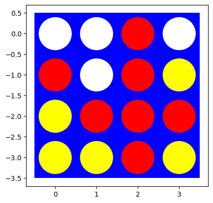

```
Player 1 wins!
```

```python
import numpy as np

ROWS = 4
COLS = 4
PLAYER1 = 1
PLAYER2 = -1

# Function to create an empty board
def create_board():
    return np.zeros((ROWS, COLS))

# Function to check if the column is valid
def is_valid_location(board, col):
    return board[ROWS-1][col] == 0

# Function to get the next open row in a column
def get_next_open_row(board, col):
    for r in range(ROWS):
        if board[r][col] == 0:
            return r

# Function to place a disc on the board
def drop_piece(board, row, col, piece):
    board[row][col] = piece

# Heuristic evaluation function
def evaluate_window(window, piece):
    score = 0
    opp_piece = PLAYER2 if piece == PLAYER1 else PLAYER1
    if window.count(piece) == 4:
        score += 100
    elif window.count(piece) == 3 and window.count(0) == 1:
        score += 5
    elif window.count(opp_piece) == 3 and window.count(0) == 1:
        score -= 4
    return score

# Score the board based on various factors
def score_position(board, piece):
    score = 0
    center_array = list(board[:, COLS//2])
    score += center_array.count(piece) * 3

    # Score horizontal lines
    for r in range(ROWS):
        row_array = list(board[r])
        for c in range(COLS-3):
            window = row_array[c:c+4]
            score += evaluate_window(window, piece)

    # Score vertical lines
    for c in range(COLS):
        col_array = list(board[:, c])
        for r in range(ROWS-3):
            window = col_array[r:r+4]
            score += evaluate_window(window, piece)

    # Score positive diagonals
    for r in range(ROWS-3):
        for c in range(COLS-3):
            window = [board[r+i][c+i] for i in range(4)]
            score += evaluate_window(window, piece)

    # Score negative diagonals
    for r in range(3, ROWS):
        for c in range(COLS-3):
            window = [board[r-i][c+i] for i in range(4)]
            score += evaluate_window(window, piece)

    return score

# Alpha-Beta algorithm for decision-making with depth cutoff
def alpha_beta(board, depth, alpha, beta, maximizing_player):
    valid_locations = [c for c in range(COLS) if is_valid_location(board, c)]
    is_terminal = len(valid_locations) == 0

    if depth == 0 or is_terminal: # Cutoff condition
        return score_position(board, PLAYER1), None

    if maximizing_player:
        value = -np.inf
        column = np.random.choice(valid_locations)
        for col in valid_locations:
            row = get_next_open_row(board, col)
            temp_board = board.copy()
            drop_piece(temp_board, row, col, PLAYER1)
            new_score, _ = alpha_beta(temp_board, depth-1, alpha, beta, False)
            if new_score > value:
                value = new_score
                column = col
            alpha = max(alpha, value)
            if alpha >= beta:
                break
        return value, column
    else:
        value = np.inf
        column = np.random.choice(valid_locations)
        for col in valid_locations:
            row = get_next_open_row(board, col)
            temp_board = board.copy()
            drop_piece(temp_board, row, col, PLAYER2)
            new_score, _ = alpha_beta(temp_board, depth-1, alpha, beta, True)
            if new_score < value:
                value = new_score
                column = col
            beta = min(beta, value)
            if beta <= alpha:
                break
        return value, column

# Function to check for a win (already implemented in your original code)

def play_game1():
    board  = [
    [0, 0, 0, 0],
    [1, 0, 1, -1],
    [-1, 1, 1, 1],
    [-1, -1, 1, -1]
]
    game_over = False
    turn = 0 # 0 for Player 1, 1 for Player 2
    depth = 4 # Search depth for the Agent
    board=np.flip(board, 0)
    while not game_over:
        current_player = PLAYER1 if turn % 2 == 0 else PLAYER2

        # Get the best move using Alpha-Beta
        score, col = alpha_beta(board, depth, -np.inf, np.inf, current_player == PLAYER1)

        # Drop the piece on the board
        row = get_next_open_row(board, col)
        drop_piece(board, row, col, current_player)

        # Print the current board
        visualize(np.flip(board, 0)) # Visualize
        # Print the current board


        # Check for win or draw
        if is_winning_move(board, current_player):
            print(f"Player {current_player} wins!")
            game_over = True
        elif np.all(board != 0): # Check for draw
            print("It's a draw!")
            game_over = True

        # Switch turns
        turn += 1

        # Start the game
play_game1()
```

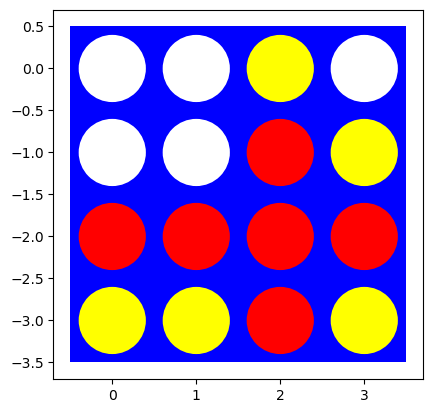

```
Player 1 wins!
```

```python
import numpy as np

ROWS = 4
COLS = 4
PLAYER1 = 1
PLAYER2 = -1

# Function to create an empty board
def create_board():
    return np.zeros((ROWS, COLS))

# Function to check if the column is valid
def is_valid_location(board, col):
    return board[ROWS-1][col] == 0

# Function to get the next open row in a column
def get_next_open_row(board, col):
    for r in range(ROWS):
        if board[r][col] == 0:
            return r

# Function to place a disc on the board
def drop_piece(board, row, col, piece):
    board[row][col] = piece

# Heuristic evaluation function
def evaluate_window(window, piece):
    score = 0
    opp_piece = PLAYER2 if piece == PLAYER1 else PLAYER1
    if window.count(piece) == 4:
        score += 100
    elif window.count(piece) == 3 and window.count(0) == 1:
        score += 5
    elif window.count(opp_piece) == 3 and window.count(0) == 1:
        score -= 4
    return score

# Score the board based on various factors
def score_position(board, piece):
    score = 0
    center_array = list(board[:, COLS//2])
    score += center_array.count(piece) * 3

    # Score horizontal lines
    for r in range(ROWS):
        row_array = list(board[r])
        for c in range(COLS-3):
            window = row_array[c:c+4]
            score += evaluate_window(window, piece)

    # Score vertical lines
    for c in range(COLS):
        col_array = list(board[:, c])
        for r in range(ROWS-3):
            window = col_array[r:r+4]
            score += evaluate_window(window, piece)

    # Score positive diagonals
    for r in range(ROWS-3):
        for c in range(COLS-3):
            window = [board[r+i][c+i] for i in range(4)]
            score += evaluate_window(window, piece)

    # Score negative diagonals
    for r in range(3, ROWS):
        for c in range(COLS-3):
            window = [board[r-i][c+i] for i in range(4)]
            score += evaluate_window(window, piece)

    return score

# Alpha-Beta algorithm for decision-making with depth cutoff
def alpha_beta(board, depth, alpha, beta, maximizing_player):
    valid_locations = [c for c in range(COLS) if is_valid_location(board, c)]
    is_terminal = len(valid_locations) == 0

    if depth == 0 or is_terminal: # Cutoff condition
        return score_position(board, PLAYER1), None

    if maximizing_player:
        value = -np.inf
        column = np.random.choice(valid_locations)
        for col in valid_locations:
            row = get_next_open_row(board, col)
            temp_board = board.copy()
            drop_piece(temp_board, row, col, PLAYER1)
            new_score, _ = alpha_beta(temp_board, depth-1, alpha, beta, False)
            if new_score > value:
                value = new_score
                column = col
            alpha = max(alpha, value)
            if alpha >= beta:
                break
        return value, column
    else:
        value = np.inf
        column = np.random.choice(valid_locations)
        for col in valid_locations:
            row = get_next_open_row(board, col)
            temp_board = board.copy()
            drop_piece(temp_board, row, col, PLAYER2)
            new_score, _ = alpha_beta(temp_board, depth-1, alpha, beta, True)
            if new_score < value:
                value = new_score
                column = col
            beta = min(beta, value)
            if beta <= alpha:
                break
        return value, column

# Function to check for a win (already implemented in your original code)

def play_game1():
    board  = [
    [0, 0, -1, 0],
    [0, 0, 1, -1],
    [0, 1, 1, 1],
    [-1, -1, 1, -1]
]
    game_over = False
    turn = 0 # 0 for Player 1, 1 for Player 2
    depth = 4 # Search depth for the Agent
    board=np.flip(board, 0)
    while not game_over:
        current_player = PLAYER1 if turn % 2 == 0 else PLAYER2

        # Get the best move using Alpha-Beta
        score, col = alpha_beta(board, depth, -np.inf, np.inf, current_player == PLAYER1)

        # Drop the piece on the board
        row = get_next_open_row(board, col)
        drop_piece(board, row, col, current_player)

        # Print the current board
        visualize(np.flip(board, 0)) # Visualize
        # Print the current board


        # Check for win or draw
        if is_winning_move(board, current_player):
            print(f"Player {current_player} wins!")
            game_over = True
        elif np.all(board != 0): # Check for draw
            print("It's a draw!")
            game_over = True

        # Switch turns
        turn += 1

        # Start the game
play_game1()
```

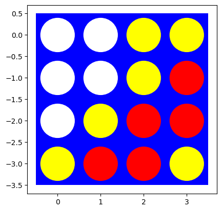

```
Player -1 wins!
```

```python
import numpy as np

ROWS = 4
COLS = 4
PLAYER1 = -1
PLAYER2 = 1

# Function to create an empty board
def create_board():
    return np.zeros((ROWS, COLS))

# Function to check if the column is valid
def is_valid_location(board, col):
    return board[ROWS-1][col] == 0

# Function to get the next open row in a column
def get_next_open_row(board, col):
    for r in range(ROWS):
        if board[r][col] == 0:
            return r

# Function to place a disc on the board
def drop_piece(board, row, col, piece):
    board[row][col] = piece

# Heuristic evaluation function
def evaluate_window(window, piece):
    score = 0
    opp_piece = PLAYER2 if piece == PLAYER1 else PLAYER1
    if window.count(piece) == 4:
        score += 100
    elif window.count(piece) == 3 and window.count(0) == 1:
        score += 5
    elif window.count(opp_piece) == 3 and window.count(0) == 1:
        score -= 4
    return score

# Score the board based on various factors
def score_position(board, piece):
    score = 0
    center_array = list(board[:, COLS//2])
    score += center_array.count(piece) * 3

    # Score horizontal lines
    for r in range(ROWS):
        row_array = list(board[r])
        for c in range(COLS-3):
            window = row_array[c:c+4]
            score += evaluate_window(window, piece)

    # Score vertical lines
    for c in range(COLS):
        col_array = list(board[:, c])
        for r in range(ROWS-3):
            window = col_array[r:r+4]
            score += evaluate_window(window, piece)

    # Score positive diagonals
    for r in range(ROWS-3):
        for c in range(COLS-3):
            window = [board[r+i][c+i] for i in range(4)]
            score += evaluate_window(window, piece)

    # Score negative diagonals
    for r in range(3, ROWS):
        for c in range(COLS-3):
            window = [board[r-i][c+i] for i in range(4)]
            score += evaluate_window(window, piece)

    return score

# Alpha-Beta algorithm for decision-making with depth cutoff
def alpha_beta(board, depth, alpha, beta, maximizing_player):
    valid_locations = [c for c in range(COLS) if is_valid_location(board, c)]
    is_terminal = len(valid_locations) == 0

    if depth == 0 or is_terminal: # Cutoff condition
        return score_position(board, PLAYER1), None

    if maximizing_player:
        value = -np.inf
        column = np.random.choice(valid_locations)
        for col in valid_locations:
            row = get_next_open_row(board, col)
            temp_board = board.copy()
            drop_piece(temp_board, row, col, PLAYER1)
            new_score, _ = alpha_beta(temp_board, depth-1, alpha, beta, False)
            if new_score > value:
                value = new_score
                column = col
            alpha = max(alpha, value)
            if alpha >= beta:
                break
        return value, column
    else:
        value = np.inf
        column = np.random.choice(valid_locations)
        for col in valid_locations:
            row = get_next_open_row(board, col)
            temp_board = board.copy()
            drop_piece(temp_board, row, col, PLAYER2)
            new_score, _ = alpha_beta(temp_board, depth-1, alpha, beta, True)
            if new_score < value:
                value = new_score
                column = col
            beta = min(beta, value)
            if beta <= alpha:
                break
        return value, column

# Function to check for a win (already implemented in your original code)

def play_game1():
    board  = [
    [0, 0, -1, 0],
    [0, 0, -1, 1],
    [0, -1, 1, 1],
    [-1, 1, 1, -1]
]
    game_over = False
    turn = 0 # 0 for Player 1, 1 for Player 2
    depth = 4 # Search depth for the Agent
    board=np.flip(board, 0)
    while not game_over:
        current_player = PLAYER1 if turn % 2 == 0 else PLAYER2

        # Get the best move using Alpha-Beta
        score, col = alpha_beta(board, depth, -np.inf, np.inf, current_player == PLAYER1)

        # Drop the piece on the board
        row = get_next_open_row(board, col)
        drop_piece(board, row, col, current_player)

        # Print the current board
        visualize(np.flip(board, 0)) # Visualize
        # Print the current board


        # Check for win or draw
        if is_winning_move(board, current_player):
            print(f"Player {current_player} wins!")
            game_over = True
        elif np.all(board != 0): # Check for draw
            print("It's a draw!")
            game_over = True

        # Switch turns
        turn += 1

        # Start the game
play_game1()
```

### Playtime [5 points]

Let two heuristic search agents (different cutoff depth, different heuristic evaluation function) compete against each other on a reasonably sized board. Since there is no randomness, you only need to let them play once.

[figure not shown]

[figure not shown]

[figure not shown]

[figure not shown]

[figure not shown]

[figure not shown]

[figure not shown]

[figure not shown]

[figure not shown]

[figure not shown]

[figure not shown]

[figure not shown]

[12 more figures not shown]

```
Player -1 wins!
```

```python
import numpy as np

ROWS = 6
COLS = 7
PLAYER1 = 1
PLAYER2 = -1

def create_board():
    return np.zeros((ROWS, COLS))

def is_valid_location(board, col):
    return board[ROWS-1][col] == 0

def get_next_open_row(board, col):
    for r in range(ROWS):
        if board[r][col] == 0:
            return r

def drop_piece(board, row, col, piece):
    board[row][col] = piece

# Heuristic 1: Focus on immediate wins/blocking
def heuristic_1(board, piece):
    score = 0
    # Simple scoring for the number of winning opportunities
    for r in range(ROWS):
        for c in range(COLS-3):
            window = [board[r][c+i] for i in range(4)]
            if window.count(piece) == 4:
                score += 100
            elif window.count(piece) == 3 and window.count(0) == 1:
                score += 5
            elif window.count(-piece) == 3 and window.count(0) == 1:
                score -= 4
    return score

# Heuristic 2: Favoring center control
def heuristic_2(board, piece):
    score = 0
    center_array = list(board[:, COLS // 2])
    score += center_array.count(piece) * 3 # Higher score for more pieces in the center
    return score

def is_winning_move(board, piece):
    # Check horizontal, vertical, and both diagonals
    for r in range(ROWS):
        for c in range(COLS-3):
            if board[r][c] == piece and board[r][c+1] == piece and board[r][c+2] == piece and board[r][c+3] == piece:
                return True
    for r in range(ROWS-3):
        for c in range(COLS):
            if board[r][c] == piece and board[r+1][c] == piece and board[r+2][c] == piece and board[r+3][c] == piece:
                return True
    for r in range(ROWS-3):
        for c in range(COLS-3):
            if board[r][c] == piece and board[r+1][c+1] == piece and board[r+2][c+2] == piece and board[r+3][c+3] == piece:
                return True
    for r in range(3, ROWS):
        for c in range(COLS-3):
            if board[r][c] == piece and board[r-1][c+1] == piece and board[r-2][c+2] == piece and board[r-3][c+3] == piece:
                return True
    return False

def minimax(board, depth, alpha, beta, maximizing_player, heuristic):
    valid_locations = [c for c in range(COLS) if is_valid_location(board, c)]
    is_terminal = len(valid_locations) == 0 or depth == 0

    if is_terminal:
        if is_winning_move(board, PLAYER1):
            return 1000000, None # Player 1 wins
        elif is_winning_move(board, PLAYER2):
            return -1000000, None # Player 2 wins
        else:
            return heuristic(board, PLAYER1), None # Evaluate using the heuristic

    if maximizing_player:
        value = -np.inf
        column = None
        for col in valid_locations:
            row = get_next_open_row(board, col)
            temp_board = board.copy()
            drop_piece(temp_board, row, col, PLAYER1)
            new_value, _ = minimax(temp_board, depth-1, alpha, beta, False, heuristic)
            if new_value > value:
                value = new_value
                column = col
            alpha = max(alpha, value)
            if beta <= alpha:
                break
        return value, column
    else:
        value = np.inf
        column = None
        for col in valid_locations:
            row = get_next_open_row(board, col)
            temp_board = board.copy()
            drop_piece(temp_board, row, col, PLAYER2)
            new_value, _ = minimax(temp_board, depth-1, alpha, beta, True, heuristic)
            if new_value < value:
                value = new_value
                column = col
            beta = min(beta, value)
            if beta <= alpha:
                break
        return value, column

def play_game():
    board = create_board()
    game_over = False
    turn = 0 # 0 for Player 1, 1 for Player 2
    depth_player1 = 4 # Cutoff depth for Player 1
    depth_player2 = 3 # Cutoff depth for Player 2

    while not game_over:
        current_player = PLAYER1 if turn % 2 == 0 else PLAYER2

        # Determine the heuristic function based on the current player
        heuristic = heuristic_1 if current_player == PLAYER1 else heuristic_2

        if current_player == PLAYER1:
            _, col = minimax(board, depth_player1, -np.inf, np.inf, True, heuristic)
        else:
            _, col = minimax(board, depth_player2, -np.inf, np.inf, True, heuristic)

        # Drop the piece on the board
        if col is not None: # Check if a valid column was found
            row = get_next_open_row(board, col)
            drop_piece(board, row, col, current_player)

        # Print the current board
        visualize(np.flip(board, 0)) # Visualize the board

        # Check for win or draw
        if is_winning_move(board, current_player):
            print(f"Player {current_player} wins!")
            game_over = True
        elif np.all(board != 0): # Check for draw
            print("It's a draw!")
            game_over = True

        # Switch turns
        turn += 1

# Start the game
play_game()
```

## Challenge task [up to +10 bonus point will be awarded separately]

Find another student and let your best agent play against the other student's best player. We will set up a class tournament on Canvas. This tournament will continue after the submission deadline.

## Graduate student advanced task: Pure Monte Carlo Search and Best First Move [10 point]

**Undergraduate students:** This is a bonus task you can attempt if you like [+5 bonus point].

### Pure Monte Carlo Search

Implement Pure Monte Carlo Search and investigate how this search performs on the test boards that you have used above.

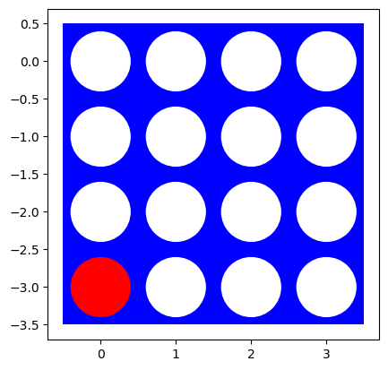

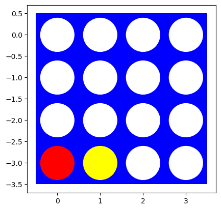

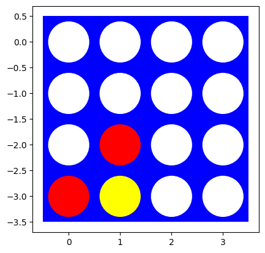

[figure not shown]

[figure not shown]

[figure not shown]

[figure not shown]

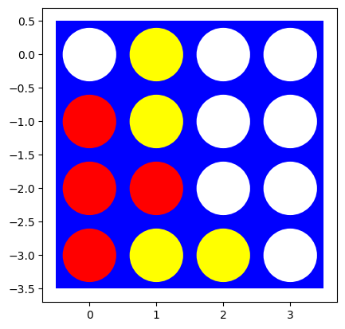

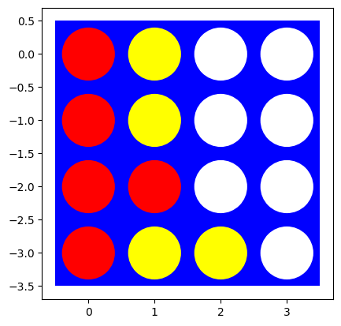

```
Player 1 wins!
```

```python
import numpy as np
import random

ROWS = 4 # Set number of rows for 4x4 board
COLS = 4 # Set number of columns for 4x4 board
PLAYER1 = 1
PLAYER2 = -1

# Function to create an empty board
def create_board():
    return np.zeros((ROWS, COLS))

# Function to check if the column is valid
def is_valid_location(board, col):
    return board[ROWS-1][col] == 0

# Function to get the next open row in a column
def get_next_open_row(board, col):
    for r in range(ROWS):
        if board[r][col] == 0:
            return r

# Function to place a disc on the board
def drop_piece(board, row, col, piece):
    board[row][col] = piece

# Function to check for a win
def is_winning_move(board, piece):
    # Check horizontal, vertical, and both diagonals for 4x4
    for r in range(ROWS):
        for c in range(COLS-3): # Check horizontally
            if board[r][c] == piece and board[r][c+1] == piece and board[r][c+2] == piece and board[r][c+3] == piece:
                return True
    for r in range(ROWS-3):
        for c in range(COLS): # Check vertically
            if board[r][c] == piece and board[r+1][c] == piece and board[r+2][c] == piece and board[r+3][c] == piece:
                return True
    for r in range(ROWS-3):
        for c in range(COLS-3): # Check positive diagonals
            if board[r][c] == piece and board[r+1][c+1] == piece and board[r+2][c+2] == piece and board[r+3][c+3] == piece:
                return True
    for r in range(3, ROWS):
        for c in range(COLS-3): # Check negative diagonals
            if board[r][c] == piece and board[r-1][c+1] == piece and board[r-2][c+2] == piece and board[r-3][c+3] == piece:
                return True
    return False

# Monte Carlo simulation function
def monte_carlo_simulation(board, piece, simulations):
    wins = 0
    for _ in range(simulations):
        temp_board = board.copy()
        current_piece = piece

        while True:
            valid_locations = [c for c in range(COLS) if is_valid_location(temp_board, c)]
            if not valid_locations:
                break # Draw if no valid moves left

            # Choose a random valid column to drop a piece
            col = random.choice(valid_locations)
            row = get_next_open_row(temp_board, col)
            drop_piece(temp_board, row, col, current_piece)

            if is_winning_move(temp_board, current_piece):
                if current_piece == PLAYER1:
                    wins += 1 # Increment wins for PLAYER1
                break # End the simulation if there's a win

            # Switch pieces
            current_piece = PLAYER1 if current_piece == PLAYER2 else PLAYER2

    return wins

# Function to get the best move using Monte Carlo Search
def get_best_move(board, piece, simulations_per_move):
    valid_locations = [c for c in range(COLS) if is_valid_location(board, c)]
    best_move = None
    best_win_rate = -1

    for col in valid_locations:
        row = get_next_open_row(board, col)
        temp_board = board.copy()
        drop_piece(temp_board, row, col, piece)

        # Simulate the rest of the game from this position
        wins = monte_carlo_simulation(temp_board, PLAYER2, simulations_per_move)

        # Calculate win rate
        win_rate = wins / simulations_per_move
        if win_rate > best_win_rate:
            best_win_rate = win_rate
            best_move = col

    return best_move

def play_game():
    board = create_board()
    game_over = False
    turn = 0 # 0 for Player 1, 1 for Player 2
    simulations_per_move = 100 # Number of simulations per move

    while not game_over:
        current_player = PLAYER1 if turn % 2 == 0 else PLAYER2

        # Get the best move using Monte Carlo Search
        col = get_best_move(board, current_player, simulations_per_move)

        # Drop the piece on the board
        if col is not None: # Check if a valid column was found
            row = get_next_open_row(board, col)

            drop_piece(board, row, col, current_player)

            # Print the current board
            visualize(np.flip(board, 0)) # Visualize the board

            # Check for win or draw
            if is_winning_move(board, current_player):
                print(f"Player {current_player} wins!")
                game_over = True
            elif np.all(board != 0): # Check for draw
                print("It's a draw!")
                game_over = True

            # Switch turns
            turn += 1

# Start the game
play_game()
```

### Best First Move

Use your Monte Carlo Search to determine what the best first move for red is? Describe under what assumptions this is the "best" first move.

[figure not shown]

[figure not shown]

[figure not shown]

[figure not shown]

[figure not shown]

[figure not shown]

[figure not shown]

[figure not shown]

[figure not shown]

```
Player 1 wins!
```

```python
import numpy as np
import random

ROWS = 6 # Set number of rows for 4x4 board
COLS = 7 # Set number of columns for 4x4 board
PLAYER1 = 1
PLAYER2 = -1

# Function to create an empty board
def create_board():
    return np.zeros((ROWS, COLS))

# Function to check if the column is valid
def is_valid_location(board, col):
    return board[ROWS-1][col] == 0

# Function to get the next open row in a column
def get_next_open_row(board, col):
    for r in range(ROWS):
        if board[r][col] == 0:
            return r

# Function to place a disc on the board
def drop_piece(board, row, col, piece):
    board[row][col] = piece

# Function to check for a win
def is_winning_move(board, piece):
    # Check horizontal, vertical, and both diagonals for 4x4
    for r in range(ROWS):
        for c in range(COLS-3): # Check horizontally
            if board[r][c] == piece and board[r][c+1] == piece and board[r][c+2] == piece and board[r][c+3] == piece:
                return True
    for r in range(ROWS-3):
        for c in range(COLS): # Check vertically
            if board[r][c] == piece and board[r+1][c] == piece and board[r+2][c] == piece and board[r+3][c] == piece:
                return True
    for r in range(ROWS-3):
        for c in range(COLS-3): # Check positive diagonals
            if board[r][c] == piece and board[r+1][c+1] == piece and board[r+2][c+2] == piece and board[r+3][c+3] == piece:
                return True
    for r in range(3, ROWS):
        for c in range(COLS-3): # Check negative diagonals
            if board[r][c] == piece and board[r-1][c+1] == piece and board[r-2][c+2] == piece and board[r-3][c+3] == piece:
                return True
    return False

# Monte Carlo simulation function
def monte_carlo_simulation(board, piece, simulations):
    wins = 0
    for _ in range(simulations):
        temp_board = board.copy()
        current_piece = piece

        while True:
            valid_locations = [c for c in range(COLS) if is_valid_location(temp_board, c)]
            if not valid_locations:
                break # Draw if no valid moves left

            # Choose a random valid column to drop a piece
            col = random.choice(valid_locations)
            row = get_next_open_row(temp_board, col)
            drop_piece(temp_board, row, col, current_piece)

            if is_winning_move(temp_board, current_piece):
                if current_piece == PLAYER1:
                    wins += 1 # Increment wins for PLAYER1
                break # End the simulation if there's a win

            # Switch pieces
            current_piece = PLAYER1 if current_piece == PLAYER2 else PLAYER2

    return wins

# Function to get the best move using Monte Carlo Search
def get_best_move(board, piece, simulations_per_move):
    valid_locations = [c for c in range(COLS) if is_valid_location(board, c)]
    best_move = None
    best_win_rate = -1

    for col in valid_locations:
        row = get_next_open_row(board, col)
        temp_board = board.copy()
        drop_piece(temp_board, row, col, piece)

        # Run Monte Carlo simulations for this move
        wins = monte_carlo_simulation(temp_board, PLAYER2, simulations_per_move)

        # Calculate win rate
        win_rate = wins / simulations_per_move
        if win_rate > best_win_rate:
            best_win_rate = win_rate
            best_move = col

    return best_move

def play_game():
    board = create_board()
    game_over = False
    turn = 0 # 0 for Player 1, 1 for Player 2
    simulations_per_move = 1000 # Number of simulations per move

    while not game_over:
        current_player = PLAYER1 if turn % 2 == 0 else PLAYER2

        # Get the best move using Monte Carlo Search for Player 1
        if current_player == PLAYER1:
            col = get_best_move(board, current_player, simulations_per_move)
        else:
            # For Player 2, choose a random valid move
            valid_locations = [c for c in range(COLS) if is_valid_location(board, c)]
            col = random.choice(valid_locations) if valid_locations else None

        # Drop the piece on the board
        if col is not None: # Check if a valid column was found
            row = get_next_open_row(board, col)
            drop_piece(board, row, col, current_player)

        # Print the current board
        visualize(np.flip(board, 0)) # Visualize the board

        # Check for win or draw
        if is_winning_move(board, current_player):
            print(f"Player {current_player} wins!")
            game_over = True
        elif np.all(board != 0): # Check for draw
            print("It's a draw!")
            game_over = True

        # Switch turns
        turn += 1

# Start the game
play_game()
```